# R Notebook

```r
library(lubridate)
#dias da semana
dwk = c("dom", "seg", "ter", "qua", "qui", "sex", "sab")
```

Novas colunas para análise: velocidade média, considerando caminho reto (distância euclidiana) - embora não reflita a relidade devido ao formato das ruas, é aplicável para analisar o deslocamento de uma maneira aproximada; dia da semana; mês; horário (pickup)

```r
db %>%  mutate(trip_duration_m = trip_duration / 60) %>% #trip_duration em minutos
        mutate(vel.media.kmph = (Dist.Euc.KM * 60) / trip_duration_m) %>% #consid.caminho direto
        mutate(dt_pickup = ymd_hms(pickup_datetime)) %>%
        mutate(dt_dropoff = ymd_hms(dropoff_datetime)) %>%
        mutate(dia.semana = wday(dt_pickup)) %>% #1=dom ~ 7=sab
        mutate(ano.mes = substr(pickup_datetime, 1, 7)) %>%
        mutate(horario = hour(dt_pickup) ) -> db2
#velocidade média
summary(db2$vel.media.kmph)
```

```
     Min.   1st Qu.    Median      Mean   3rd Qu.      Max.
    0.015    10.382    14.400    16.274    19.915 10769.128
```

Detectado muitos outliers (ex.: Max > 10000 km/h)

Regressão **Tempo de viagem vs KM

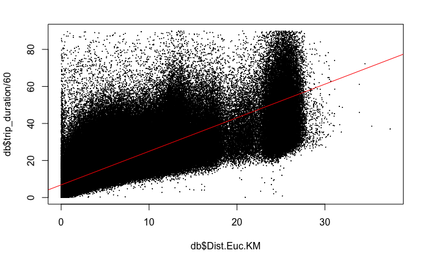

```r
plot(x=db$Dist.Euc.KM, y=db$trip_duration/60, pch=20, cex=.1)
m = lm(db$trip_duration/60 ~ db$Dist.Euc.KM)
abline(m, col="red")
```

```r
rm(m)
```

Tempo de viagem vs Km - Terça-feira

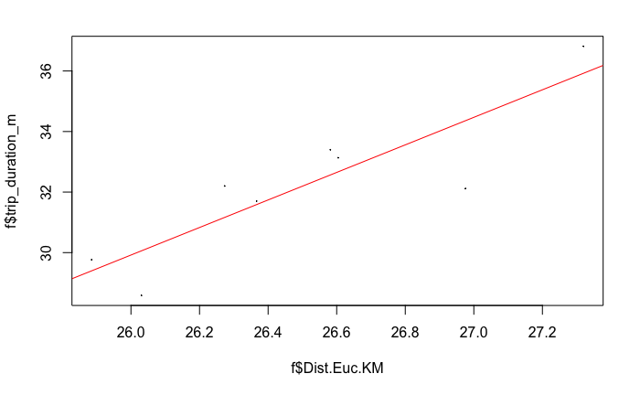

```r
f1 = filter(db2, dia.semana == 3)
f2 = filter(f1, horario == 5)
f3 = filter(f2, cluster_pickup == 4)
f = filter(f3, cluster_dropoff == 3)
plot(x=f$Dist.Euc.KM, y=f$trip_duration_m, pch=20, cex=.1)
m = lm(f$trip_duration_m ~ f$Dist.Euc.KM)
abline(m, col="red")
```

```r
rm(m, f)
```

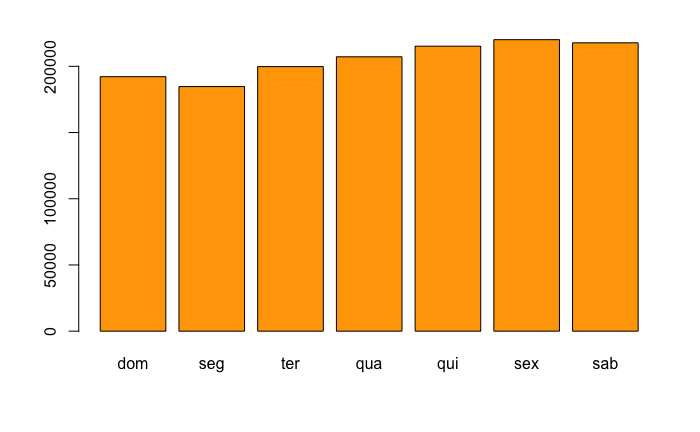

```r
#hist(db2$dia.semana, breaks=0:7, freq=FALSE, labels=dwk, main="Dia da semana")
db2 %>% group_by(dia.semana) %>% summarize(qtd = n()) -> qtd
barplot(qtd$qtd, names.arg=dwk[qtd$dia.semana], col="orange")
```

```r
rm(qtd)
```

Velocidade média por dia da semana

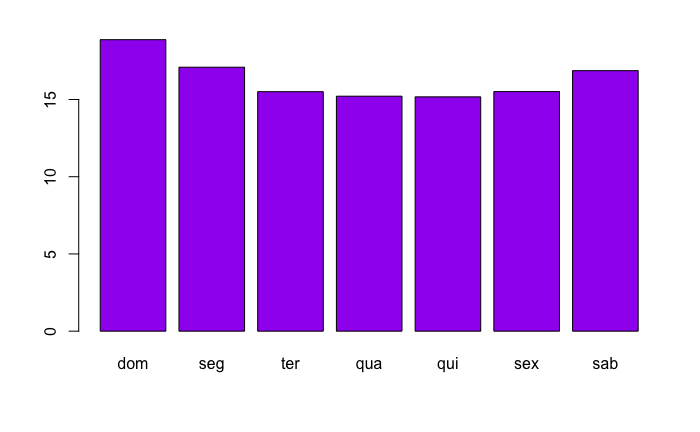

```r
db2 %>% group_by(dia.semana) %>% summarize(kmph_avg = mean(vel.media.kmph)) -> vm
barplot(vm$kmph_avg, names.arg=dwk[vm$dia.semana], col="purple")
```

```r
rm(vm)
```

Viagens por horário

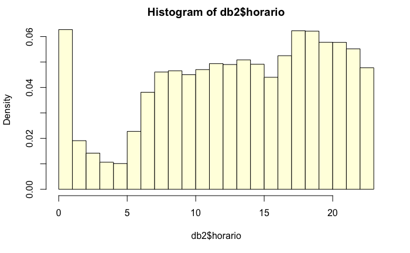

```r
hist(db2$horario, freq=FALSE, col="light yellow")
```

Velocidade média por horário

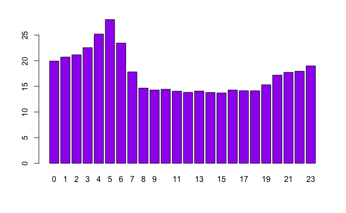

```r
db2 %>% group_by(horario=floor(horario)) %>% summarize(kmph_avg = mean(vel.media.kmph)) -> vm
barplot(vm$kmph_avg, names.arg=vm$horario, col="purple")
```

```r
rm(vm)
```

```r
library(lubridate)
#dias da semana
dwk = c("dom", "seg", "ter", "qua", "qui", "sex", "sab")
```

Novas colunas para análise: velocidade média, considerando caminho reto (distância euclidiana) - embora não reflita a relidade devido ao formato das ruas, é aplicável para analisar o deslocamento de uma maneira aproximada; dia da semana; mês; horário (pickup)

```r
db %>%  mutate(trip_duration_m = trip_duration / 60) %>% #trip_duration em minutos
        mutate(vel.media.kmph = (Dist.Euc.KM * 60) / trip_duration_m) %>% #consid.caminho direto
        mutate(dt_pickup = ymd_hms(pickup_datetime)) %>%
        mutate(dt_dropoff = ymd_hms(dropoff_datetime)) %>%
        mutate(dia.semana = wday(dt_pickup)) %>% #1=dom ~ 7=sab
        mutate(ano.mes = substr(pickup_datetime, 1, 7)) %>%
        mutate(horario = hour(dt_pickup) ) -> db2

#velocidade média
summary(db2$vel.media.kmph)
```

Detectado muitos outliers (ex.: Max > 10000 km/h)

Regressão **Tempo de viagem vs KM

```r
plot(x=db$Dist.Euc.KM, y=db$trip_duration/60, pch=20, cex=.1)
m = lm(db$trip_duration/60 ~ db$Dist.Euc.KM)
abline(m, col="red")
rm(m)
```

Tempo de viagem vs Km - Terça-feira

```r
f1 = filter(db2, dia.semana == 3)
f2 = filter(f1, horario == 5)
f3 = filter(f2, cluster_pickup == 4)
f = filter(f3, cluster_dropoff == 3)


plot(x=f$Dist.Euc.KM, y=f$trip_duration_m, pch=20, cex=.1)
m = lm(f$trip_duration_m ~ f$Dist.Euc.KM)
abline(m, col="red")
rm(m, f)
```

```r
#hist(db2$dia.semana, breaks=0:7, freq=FALSE, labels=dwk, main="Dia da semana")
db2 %>% group_by(dia.semana) %>% summarize(qtd = n()) -> qtd
barplot(qtd$qtd, names.arg=dwk[qtd$dia.semana], col="orange")
rm(qtd)
```

Velocidade média por dia da semana

```r
db2 %>% group_by(dia.semana) %>% summarize(kmph_avg = mean(vel.media.kmph)) -> vm
barplot(vm$kmph_avg, names.arg=dwk[vm$dia.semana], col="purple")
rm(vm)
```

Viagens por horário

```r
hist(db2$horario, freq=FALSE, col="light yellow")
```

Velocidade média por horário

```r
db2 %>% group_by(horario=floor(horario)) %>% summarize(kmph_avg = mean(vel.media.kmph)) -> vm
barplot(vm$kmph_avg, names.arg=vm$horario, col="purple")
rm(vm)
```